# Quant: Assignment 5

Samantha Page + Lamei Zhang

11/23/2021

# Research Question

How does affordable housing impact property value? Specifically for the purposes of this assignment, what is the relationship between affordable housing (defined as the use of a Low-income Housing Tax Credit, or LIHTC) and property values in San Francisco, California, between 2013-14 and 2018-19?

## Prior Research

In a policy brief written by the Center for Housing Policy (n.d.), findings suggest that affordable housing generally does not have significant impacts on surrounding property values, though the effects vary based on specific context. For example, clustered developments showed some negative impact on housing developments, while more diffuse development of physical affordable housing structures had little to no impact. Nguyen (2005) confirms these findings in her literature review “Does Affordable Housing Detrimentally Affect Property Values?” Nguyen generally concludes that when affordable housing is developed in depressed neighborhoods and when the quality of the housing is poor, the values of proximate property are shown to decline. Conversely, the review found no effect of affordable housing on property values when developed to good quality standards and in healthy neighborhoods. Nguyen advocates for more studies to reach more conclusive understandings.

# Data

The sample population for this study is census tracts in San Francisco, California. The analysis will include the following variables:

- San Francisco property values (2013-2014, 2018-2019) (San Francisco Recorder-Assessor)
- Affordable housing subsidized through the Low-Income Housing Tax Credit, defined by census tract (HUD)
- Median income per census tract, and median income as percent of AMI (US Census Bureau 2019)

## Load Data

```r
sf_1314 <- read_csv("sf_tax_1314.csv")

names(sf_1314)[1] <- 'Site'

names(sf_1314)[32] <- 'LandValue_1314'

names(sf_1314)[33] <- 'PropValue_1314'

sf_1314 <- sf_1314 %>%
  select(Site, block_num, lot_num, LandValue_1314, PropValue_1314) %>%
  mutate(TotValue_1314 = PropValue_1314 + LandValue_1314)
```

```r
sf_1819 <- read_csv("sf_tax_1819.csv")

names(sf_1819)[1] <- 'Site'

names(sf_1819)[32] <- 'LandValue_1819'

names(sf_1819)[33] <- 'PropValue_1819'

sf_1819 <- sf_1819 %>%
  select(Site, block_num, lot_num, LandValue_1819, PropValue_1819) %>%
    mutate(TotValue_1819 = PropValue_1819 + LandValue_1819)
```

```r
parcels_census <- read_csv("table_parcels_census.csv")

names(parcels_census)[5] <- 'block_lot'

names(parcels_census)[10] <- 'street_name'

parcels_census <- parcels_census %>%
  select(block_lot, block_num, lot_num, street_name, geoid10)
```

```r
lihtc <- read_csv("LIHTCPUB.CSV")

lihtc <- lihtc %>%
  filter(proj_cty == "SAN FRANCISCO")

names(lihtc)[15] <- 'geoid10'

lihtc <- lihtc %>%
  mutate(aff_housing = ifelse(!is.na(project), "Yes", "No")) %>%
  select(geoid10, aff_housing)
```

```r
acs_vars <- load_variables(2019, "acs5")

acs_income <- get_acs(geography = "tract",
                  variables = c(med_income_ = "B06011_001"), state = "CA", county = "San Francisco", output = "wide")

table_acs_income <- read.csv("acs_income.csv")

names(table_acs_income)[1] <- 'geoid10'

table_acs_income <- table_acs_income %>%
  select(geoid10, med_income_E, med_income_M)

acs_tenure <- get_acs(geography = "tract",
                   variables = c(owner_occ = "B25003_002", total_occ ="B25003_001"), state = "CA",
                   county = "San Francisco",
                   output = "wide")

owner_total <- acs_tenure %>%
  mutate(pct_owner = (owner_occE/total_occE)*100) %>%
  mutate(geoid10 = substr(GEOID,2,11)) %>%
  select(geoid10, owner_occE, total_occE, pct_owner)

acs_race <- get_acs(geography = "tract",
                    variables = c(pop_white = "B02001_002", pop_total = "B02001_001"), state = "CA",
                    county = "San Francisco",
                    output = "wide")

acs_race <- acs_race %>%
  mutate(pct_white = (pop_whiteE/pop_totalE)*100) %>%
  mutate(geoid10 = substr(GEOID,2,11)) %>%
  select(geoid10, pop_whiteE, pop_totalE, pct_white)
```

## Joining Data

```r
table_prop_value <- left_join(sf_1314, sf_1819) %>%
  mutate(pct_change = ((TotValue_1314 - TotValue_1819)/TotValue_1314)*-100) %>%
  mutate(newpropval = ifelse(pct_change > 0.0, "Increase", "Decrease")) %>%
  select(Site, block_num, lot_num, TotValue_1314, TotValue_1819, pct_change, newpropval)
```

```r
table_prop_value$block_num<-as.character(table_prop_value$block_num)

table_prop_parcels_census <- left_join(table_prop_value, parcels_census)
table_prop_parcels_census <- table_prop_parcels_census %>%
  select(geoid10, TotValue_1314, TotValue_1819, pct_change, newpropval) %>%
  filter(pct_change != "NA") %>%
  filter(pct_change != "NaN") %>%
  filter(pct_change != "Inf")

names(table_prop_parcels_census)[1] <- 'geoid10'
```

```r
avg_prop_tract <- read.csv("prop_parcels_census_lz.csv")

avg_prop_tract$geoid10<-as.character(avg_prop_tract$geoid10)

table_prop_lihtc <- left_join(avg_prop_tract, lihtc) %>%
   mutate(AH = ifelse(!is.na(aff_housing), "Yes", "No")) %>%
  select(geoid10, avg_1314, avg_1819, AH)
table_prop_lihtc$geoid10<-as.character(table_prop_lihtc$geoid10)

table_prop_lihtc_owner <- left_join(table_prop_lihtc, owner_total) %>%
  select(geoid10, avg_1314, avg_1819, AH, pct_owner)
table_prop_lihtc_owner_race <- left_join(table_prop_lihtc_owner, acs_race)
table_clean <- table_prop_lihtc_owner_race %>%
  distinct(geoid10, .keep_all = TRUE)
```

```r
data1 <- table_clean %>%
  mutate(pct_change = ((avg_1314 - avg_1819)/avg_1314)*-100) %>%
  mutate(newpropval = ifelse(pct_change > 0.0, "Increase", "Decrease"))
```

```r
table_acs_income$geoid10<-as.character(table_acs_income$geoid10)

data2 <- left_join(data1, table_acs_income)
data <- data2 %>%
  mutate(pct_AMI = (med_income_E / 143100)*100) %>%
  filter(geoid10 != "NA") %>%
  select(geoid10, avg_1314, avg_1819, pct_change, pct_AMI, pct_owner, pct_white, AH)
```

## Produce Table

```r
kable(head(data))
```

| geoid10 | avg_1314 | avg_1819 | pct_change | pct_AMI | pct_owner | pct_white | AH |
| --- | --- | --- | --- | --- | --- | --- | --- |
| 6075010200 | 652560.9 | 897564.4 | 37.54491 | 63.67715 | 38.449304 | 82.07343 | No |
| 6075010100 | 864769.0 | 1553283.5 | 79.61830 | 19.56674 | 8.431953 | 41.73309 | Yes |
| 6075010300 | 437288.9 | 606738.6 | 38.75005 | 52.32704 | 23.997971 | 66.34549 | No |
| 6075010500 | 1866477.2 | 2241248.6 | 20.07908 | 61.53459 | 18.176539 | 55.41562 | Yes |
| 6075010400 | 445074.4 | 630320.6 | 41.62139 | 53.59050 | 38.295269 | 69.22399 | No |
| 6075010700 | 455307.2 | 601555.0 | 32.12069 | 11.43885 | 5.354331 | 16.76280 | No |

This dataset includes 194 observations.

# Descriptive Statistics

## Continuous Variables

The continuous variables we want to use are percent change of property value per census tract between 2013-14 and 2018-19, average property value per census tract in 2018-19, and median income per tract as a percentage of 100% AMI ($143,100).

### Sample Mean and 95-percent Confidence Interval

```r
prop_t_test <- t.test(data$pct_change)
avg_1819_t_test <- t.test(data$avg_1819)
AMI_t_test <- t.test(data$pct_AMI)
owner_t_test <- t.test(data$pct_owner)
white_t_test <- t.test(data$pct_white)
```

### Median and Interquartile Range

```r
prop_quartiles <- quantile(data$pct_change, na.rm = TRUE)
avg_1819_quartiles <- quantile(data$avg_1819, na.rm = TRUE)
AMI_quartiles <- quantile(data$pct_AMI, na.rm = TRUE)
owner_quartiles <- quantile(data$pct_owner, na.rm = TRUE)
white_quartiles <- quantile(data$pct_white, na.rm = TRUE)
```

### Standard Deviation

```r
prop_st_dev <- sd(data$pct_change, na.rm = TRUE)
avg_1819_st_dev <- sd(data$avg_1819, na.rm = TRUE)
AMI_st_dev <- sd(data$pct_AMI, na.rm = TRUE)
owner_st_dev <- sd(data$pct_owner, na.rm = TRUE)
white_st_dev <- sd(data$pct_white, na.rm = TRUE)
```

### Histograms

```r
prop_hist <- ggplot(data) +
  geom_histogram(aes(x = pct_change),
                 bins = 100) +
  scale_x_continuous(trans = "log")

avg_1819_hist <- ggplot(data) +
  geom_histogram(aes(x = avg_1819),
                 bins = 100) +
  scale_x_continuous(trans = "log")

AMI_hist <- ggplot(data) +
  geom_histogram(aes(x = pct_AMI),
                 bins = 30)
  #scale_x_continuous(trans = "log")

owner_hist <-  ggplot(data) +
  geom_histogram(aes(x = pct_owner),
                 bins = 30)

white_hist <-  ggplot(data) +
  geom_histogram(aes(x = pct_white),
                 bins = 30)
```

## Displaying Results

### Formatted Table

```r
cont_summary <- tibble(
  Variable = c("Change of property value (%)",
               "Average property value per census tract in 2018-19",
               "Income as percent of AMI (%)",
               "Percent of homes occupied by owners (%)",
               "Percent of white people (%)"),
  `Sample mean` = c(prop_t_test$estimate,
                    avg_1819_t_test$estimate,
                    AMI_t_test$estimate,
                    owner_t_test$estimate,
                    white_t_test$estimate),
  `Population mean (95% confidence) - low` =
    c(prop_t_test$conf.int[1],
      avg_1819_t_test$conf.int[1],
      AMI_t_test$conf.int[1],
      owner_t_test$conf.int[1],
      white_t_test$conf.int[1]),
  `Population mean (95% confidence) - high` =
    c(prop_t_test$conf.int[2],
      avg_1819_t_test$conf.int[2],
      AMI_t_test$conf.int[2],
      owner_t_test$conf.int[2],
      white_t_test$conf.int[2]),
  Median = c(prop_quartiles[3],
             avg_1819_quartiles[3],
             AMI_quartiles[3],
             owner_quartiles[3],
             white_quartiles[3]),
  `Interquartile range` = c(prop_quartiles[4] - prop_quartiles[2],
                            avg_1819_quartiles[4] - avg_1819_quartiles[2],
                            AMI_quartiles[4] - AMI_quartiles[2],
                            owner_quartiles[4] - owner_quartiles[2],
                            white_quartiles[4] - white_quartiles[2]),
  `Standard deviation` = c(prop_st_dev,
                           avg_1819_st_dev,
                          AMI_st_dev,
                          owner_st_dev,
                          white_st_dev))

kable(cont_summary, digits = 0)
```

| Variable | Sample mean | Population mean (95% confidence) - low | Population mean (95% confidence) - high | Median | Interquartile range | Standard deviation |
| --- | --- | --- | --- | --- | --- | --- |
| Change of property value (%) | 42 | 39 | 45 | 40 | 11 | 18 |
| Average property value per census tract in 2018-19 | 844251 | 646651 | 1041851 | 503100 | 354911 | 1395432 |
| Income as percent of AMI (%) | 40 | 38 | 43 | 37 | 30 | 19 |
| Percent of homes occupied by owners (%) | 39 | 36 | 43 | 38 | 39 | 24 |
| Percent of white people (%) | 48 | 45 | 51 | 48 | 33 | 21 |

### Row of Histograms

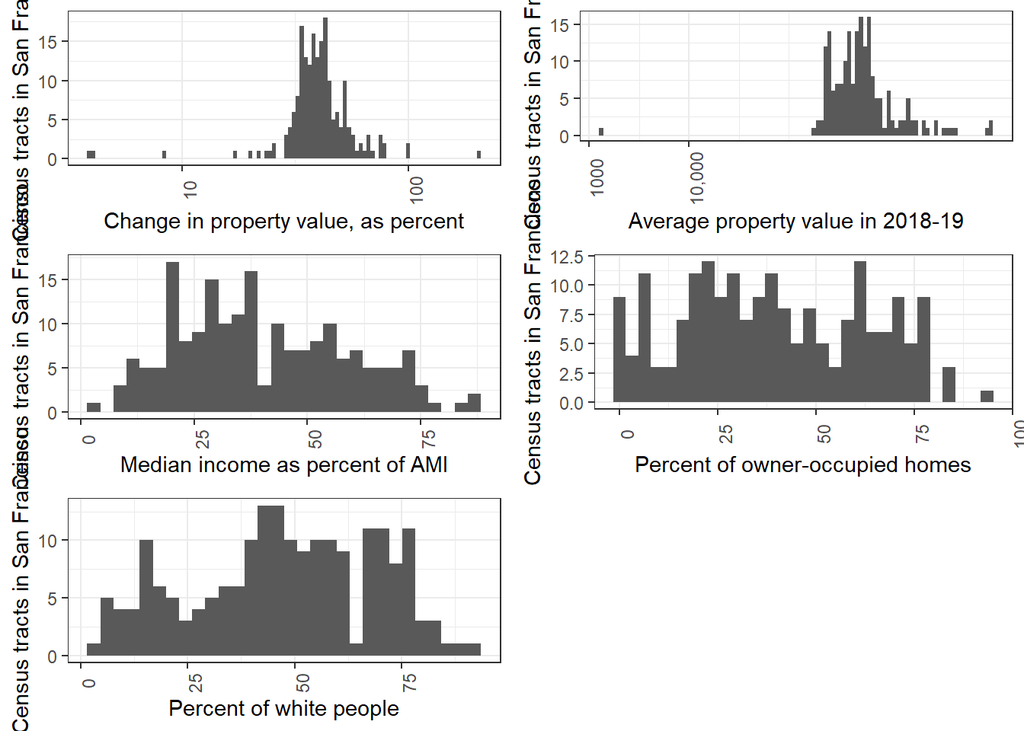

```r
pretty_prop_hist = prop_hist +
  theme_bw() +
  scale_x_continuous(name = "Change in property value, as percent",
                     trans = "log",
                     breaks = c(0.1, 1, 10, 100, 1000, 10000),
                     labels = c("0.1", "1", "10", "100", "1000", "10,000")) +
  scale_y_continuous(name = "Census tracts in San Francisco") +
  theme(axis.text.x = element_text(angle = 90))
pretty_avg_1819_hist <- avg_1819_hist +
  theme_bw() +
  scale_x_continuous(name = "Average property value in 2018-19",
                     trans = "log",
                     breaks = c(0.1, 1, 10, 100, 1000, 10000),
                     labels = c("0.1", "1", "10", "100", "1000", "10,000")) +
  scale_y_continuous(name = "Census tracts in San Francisco") +
  theme(axis.text.x = element_text(angle = 90))
pretty_AMI_hist <- AMI_hist +
  theme_bw() +
  scale_x_continuous(name = "Median income as percent of AMI",) +
  scale_y_continuous(name = "Census tracts in San Francisco") +
  theme(axis.text.x = element_text(angle = 90))

pretty_owner_hist <- owner_hist +
  theme_bw() +
  scale_x_continuous(name = "Percent of owner-occupied homes",) +
  scale_y_continuous(name = "Census tracts in San Francisco") +
  theme(axis.text.x = element_text(angle = 90))

pretty_white_hist <- white_hist +
  theme_bw() +
  scale_x_continuous(name = "Percent of white people",) +
  scale_y_continuous(name = "Census tracts in San Francisco") +
  theme(axis.text.x = element_text(angle = 90))

grid.arrange(pretty_prop_hist, pretty_avg_1819_hist, pretty_AMI_hist, pretty_owner_hist, pretty_white_hist,
             ncol = 2)
```

## Categorical Variables

We have one categorical variable:

- whether affordable housing was present in the census tract

```r
AH_yes <- t.test(data$AH == "Yes")
AH_no <- t.test(data$AH == "No")
```

```r
cat_summary_AH <- tibble(`Affordable housing` =
                              c("Yes",
                                "No"),
                            `Sample proportion` =
                              c(AH_yes$estimate * 100,
                                AH_no$estimate * 100),
                            `95-percent confidence - low` =
                              c(AH_yes$conf.int[1] * 100,
                                AH_no$conf.int[1] * 100),
                            `95-percent confidence - high` =
                              c(AH_yes$conf.int[2] * 100,
                                AH_no$conf.int[2] * 100))

kable(cat_summary_AH, digits = 0)
```

| Affordable housing | Sample proportion | 95-percent confidence - low | 95-percent confidence - high |
| --- | --- | --- | --- |
| Yes | 35 | 28 | 42 |
| No | 65 | 58 | 72 |

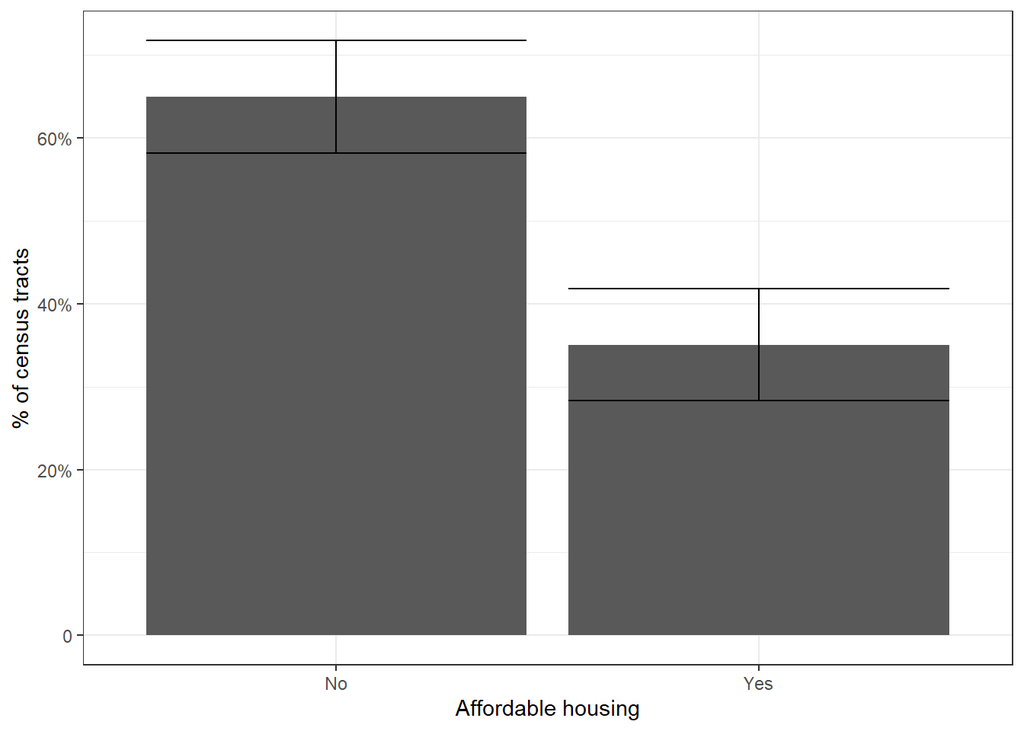

```r
ggplot(cat_summary_AH) +
  geom_bar(aes(x = `Affordable housing`,
               y = `Sample proportion`),
           stat = "identity") +
  geom_errorbar(aes(x = `Affordable housing`,
               y = `Sample proportion`,
               ymin = `95-percent confidence - low`,
               ymax = `95-percent confidence - high`),
           stat = "identity") +
  scale_y_continuous(name = "% of census tracts",
                     breaks = c(0, 20, 40, 60, 80),
                     labels = c("0", "20%", "40%", "60%", "80%")) +
  theme_bw()
```

# Bivariate Regression Analysis

The dependent variable is the percent change in property values between 2013-14 and 2018-18. The independent variables are average property value per census tract in 2018-19, median income as percent of AMI, percent of owner-occupied housing, and presence of affordable housing.

## Average Property Values in 2018-19

```r
cor.test(~ pct_change + avg_1819, data = data)
```

```
##
##  Pearson's product-moment correlation
##
## data:  pct_change and avg_1819
## t = 1.1063, df = 192, p-value = 0.27
## alternative hypothesis: true correlation is not equal to 0
## 95 percent confidence interval:
##  -0.06198095  0.21801921
## sample estimates:
##        cor
## 0.07958882
```

The 95-percent confidence interval for the correlation between percent change in property value and average property value in 2018-19 includes 0, and has a very high p-value, so we cannot confidently say there is any relationship between these two variables.

## Median Income as Percent of AMI

```r
cor.test(~ pct_change + pct_AMI, data = data)
```

```
##
##  Pearson's product-moment correlation
##
## data:  pct_change and pct_AMI
## t = -0.88068, df = 191, p-value = 0.3796
## alternative hypothesis: true correlation is not equal to 0
## 95 percent confidence interval:
##  -0.20301157  0.07834897
## sample estimates:
##         cor
## -0.06359491
```

The 95-percent confidence interval for the correlation between percent change in property value and income as percent of AMI includes 0, and has an even higher p-value, so we cannot confidently say there is any relationship between these two variables.

## Housing Tenure

```r
cor.test(~ pct_change + pct_owner, data = data)
```

```
##
##  Pearson's product-moment correlation
##
## data:  pct_change and pct_owner
## t = -1.3039, df = 192, p-value = 0.1938
## alternative hypothesis: true correlation is not equal to 0
## 95 percent confidence interval:
##  -0.23150696  0.04781836
## sample estimates:
##        cor
## -0.0936876
```

The 95-percent confidence interval for the correlation between percent change of property value and percent of tract with owner-occupied housing includes 0, and the p-value is much higher than 0.05, so we cannot confidently say anything about this relationship either.

## White People

```r
cor.test(~ pct_change + pct_white, data = data)
```

```
##
##  Pearson's product-moment correlation
##
## data:  pct_change and pct_white
## t = -0.44828, df = 192, p-value = 0.6545
## alternative hypothesis: true correlation is not equal to 0
## 95 percent confidence interval:
##  -0.1724240  0.1090369
## sample estimates:
##         cor
## -0.03233458
```

## Presence of Affordable Housing

```r
t.test(pct_change ~ AH, data)
```

```
##
##  Welch Two Sample t-test
##
## data:  pct_change by AH
## t = -2.8575, df = 90.259, p-value = 0.005301
## alternative hypothesis: true difference in means between group No and group Yes is not equal to 0
## 95 percent confidence interval:
##  -15.216826  -2.735766
## sample estimates:
##  mean in group No mean in group Yes
##          38.93417          47.91047
```

The p-value is less than 0.05, which means the relationship between percent change of property value and the presence of affordable housing is significant. It seems that a higher percent change in property value is associated with the presence of affordable housing.

# Multivariate Regression Analysis

```r
full_model <- lm(pct_change ~ avg_1314 + pct_AMI + AH + pct_owner + pct_white, data)

summary(full_model)
```

```
##
## Call:
## lm(formula = pct_change ~ avg_1314 + pct_AMI + AH + pct_owner +
##     pct_white, data = data)
##
## Residuals:
##     Min      1Q  Median      3Q     Max
## -84.476  -6.649  -1.322   4.189 154.351
##
## Coefficients:
##               Estimate Std. Error t value Pr(>|t|)
## (Intercept)  4.410e+01  5.291e+00   8.336 1.63e-14 ***
## avg_1314    -1.702e-06  1.227e-06  -1.387  0.16719
## pct_AMI     -9.852e-02  1.386e-01  -0.711  0.47823
## AHYes        7.909e+00  2.909e+00   2.719  0.00717 **
## pct_owner   -4.559e-02  6.921e-02  -0.659  0.51092
## pct_white    4.206e-02  1.251e-01   0.336  0.73710
## ---
## Signif. codes:  0 '***' 0.001 '**' 0.01 '*' 0.05 '.' 0.1 ' ' 1
##
## Residual standard error: 17.93 on 187 degrees of freedom
##   (1 observation deleted due to missingness)
## Multiple R-squared:  0.06805,    Adjusted R-squared:  0.04313
## F-statistic: 2.731 on 5 and 187 DF,  p-value: 0.02087
```

This multivariate regression confirms what we saw in the bivariate regressions. Controlling for all other variables, we find that the only statistically significant predictor of property value change is the presence of affordable housing and that there is still no significant relationship between percent change of property values and property values in 2013-14, median income, and housing tenure. One thing that we noted is that while affordable housing is still a predictor of affordable housing change, the magnitude is slightly lower when we control for all other variables, going from 8.9% to 7.8%.

This model explains about 6.7% of the variation in tract-level property value change in San Francisco from 2013-14 to 2018-19.

# Transformation

```r
data_log <- data %>%
  mutate(log2_inctot = log(pct_AMI, base = 2),
         log2_whitetot = log(pct_white, base = 2))

coff_name_scaled <- c("Constant" = "(Intercept)",
                      "Percent White" = "pct_white",
                      "Double the % of White People" = "log2_whitetot",
                      "Median Income as AMI" = "pct_AMI",
                      "Double the Median Income" = "log2_inctot",
                      "Percent Homeowner" = "pct_owner",
                      "Property Value in 2013-14" = "avg_1314",
                      "Presence of Affordable" = "AHYes")

data_log_scaled <- lm(pct_change ~ pct_white + log2_whitetot  + pct_AMI + log2_inctot + pct_owner  + avg_1314 + AH, data_log)

export_summs(full_model, data_log_scaled,
             error_format = "(p = {p.value})",
             error_pos = "same",
             model.names = c("Initial\n(change per census tract)",
                             "Logged\n(change per census tract)"),
             coefs = coff_name_scaled)
```

|  | Initial (change per census tract) | Logged (change per census tract) |
| --- | --- | --- |
| Constant | 44.10 *** (p = 0.00) | 8.24 (p = 0.69) |
| Percent White | 0.04 (p = 0.74) | -0.13 (p = 0.58) |
| Double the % of White People |  | 2.77 (p = 0.54) |
| Median Income as AMI | -0.10 (p = 0.48) | -0.35 (p = 0.18) |
| Double the Median Income |  | 8.12 (p = 0.18) |
| Percent Homeowner | -0.05 (p = 0.51) | -0.09 (p = 0.22) |
| Property Value in 2013-14 | -0.00 (p = 0.17) | -0.00 (p = 0.16) |
| Presence of Affordable | 7.91 ** (p = 0.01) | 7.16 * (p = 0.02) |
| N | 193 | 193 |
| R2 | 0.07 | 0.08 |
| *** p < 0.001; ** p < 0.01; * p < 0.05. |  |  |

We log transformed (with a base of 2) the median income as percent of AMI and the percentage of white people per census tract to see what effect doubling those two variables would have on their significance. The transformed variables are still not significant in this model, and the presence of affordable housing is statistically significant at a slightly smaller confidence interval than we observed in the initial model. However, the R squared value is very slightly higher, so the transformed model is our preferred version.

# References

- Center for Housing Policy. n.d. “‘Don’t Put it Here!’ Does Affordable Housing Cause Nearby Property Values to Decline?” Insights from Housing Policy Research. https://furmancenter.org/files/media/Dont_Put_It_Here.pdf.
- Nguyen, Mai Thi. 2005. “Does Affordable Housing Detrimentally Affect Property Values? A Review of the Literature.” Journal of Planning Literature 20, no. 1: 15-26. https://10.1177/0885412205277069
- PolicyMap. 2019. Location of publicly funded housing within San Francisco [Map]. https://harvard-policymap-com.ezp-prod1.hul.harvard.edu/maps?p=100385&o=101450,101500,96400,162200,150100,165200,306250&cx=-122.38390910801226&cy=37.80951024596563&cz=8
- San Francisco City & County, Office of Assessor-Recorder. n.d. Secured Property Tax Data. http://sfassessor.org/news-information/property-data-0